# Machine Learning in Python: *k*-Nearest Neighbours Regression

⇦ Back

# 1 Python Packages

The code on this page uses the scikit-learn, Matplotlib, pandas and NumPy packages. These can be installed from the terminal with the following commands:

```bash
# "python3.12" corresponds to the version of Python you have installed and are using
$ python3.12 -m pip install scikit-learn
$ python3.12 -m pip install matplotlib
$ python3.12 -m pip install pandas
$ python3.12 -m pip install numpy
```

Once installed, import these packages into your Python script as follows:

```python
from sklearn import datasets
from sklearn import model_selection
from sklearn import neighbors
from matplotlib import pyplot as plt
from matplotlib import cm
from matplotlib import colors
import pandas as pd
import numpy as np
```

# 2 Example Data

For this example we will use the *diabetes* toy dataset from scikit-learn:

- See [here](https://scikit-learn.org/stable/datasets/toy_dataset.html#diabetes-dataset) for the user guide
- See [here](https://scikit-learn.org/stable/modules/generated/sklearn.datasets.load_diabetes.html) for the documentation of the `load_diabetes()` function which imports this dataset
- See here for an example that uses this dataset
- See [here](https://www4.stat.ncsu.edu/~boos/var.select/diabetes.html) for the ‘homepage’ of this dataset
- See [here](https://hastie.su.domains/Papers/LARS/LeastAngle_2002.pdf) for the original publication

This dataset can be loaded using the `load_diabetes()` function from scikit-learn’s `datasets` sub-module. Using the `as_frame=True` option means that the data will be formatted as a pandas data frame:

```python
# Load the dataset
dataset = datasets.load_diabetes(as_frame=True)
```

```python
# Separate out the features
cols = ['bmi', 's6']
X = dataset['data'][cols]

# View the first five rows
print(X[:5])
```

```
##         bmi        s6
## 0  0.061696 -0.017646
## 1 -0.051474 -0.092204
## 2  0.044451 -0.025930
## 3 -0.011595 -0.009362
## 4 -0.036385 -0.046641
```

The target is a quantitative measure of disease progression one year after baseline:

```python
# Separate out the target
y = dataset['target']

# View the first five values
print(y.head())
```

```
## 0    151.0
## 1     75.0
## 2    141.0
## 3    206.0
## 4    135.0
## Name: target, dtype: float64
```

The example data will get split into a training and a testing set:

```python
# Split into training and testing sets
X_train, X_test, y_train, y_test = model_selection.train_test_split(
    X, y, random_state=20231003, test_size=0.3
)
```

# 3 Visualise the Training Set

Now let’s have a look at the raw data:

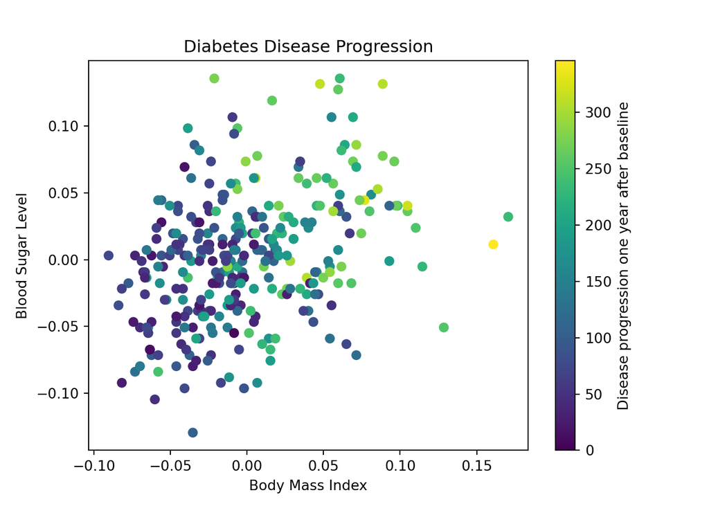

```python
# Plot
ax = plt.axes()
ax.scatter(X_train['bmi'], X_train['s6'], c=y_train, cmap='viridis')
ax.set_title('Diabetes Disease Progression')
ax.set_ylabel('Blood Sugar Level')
ax.set_xlabel('Body Mass Index')
label = 'Disease progression one year after baseline'
norm = colors.Normalize(vmin=0, vmax=y_train.max())
plt.colorbar(cm.ScalarMappable(cmap='viridis', norm=norm), ax=ax, label=label)
plt.show()
plt.close()
```

As you can see, as BMI and blood sugar increases the more ‘yellow’ the points become, ie the more disease progression increases.

# 4 Overview of the Algorithm

What we want to do now is build a model that will predict the severity of a new patient’s disease progression given their BMI and blood sugar level, and we will use a *k*-nearest neighbors (*k*-NN) algorithm to do so. In general, this algorithm will:

1. Plot a new point on the above graph
2. Find the *k* nearest existing points
3. Calculate the average disease progression value of these *k* points
4. Set the disease progression value of the new point equal to this average value

For example, in a three-nearest neighbours algorithm, if a new point (consisting of a BMI value and a blood sugar value) is plotted on the above graph and the three existing points which are nearest to it have an average disease progression value of 200 (ie they are mostly green) then the new point will be given a value of 200 (and will be shown in green too).

See the [Wikipedia page](https://en.wikipedia.org/wiki/K-nearest_neighbors_algorithm) for the *k*-nearest neighbors algorithm for more info.

# 5 Create the Model

We will use the `KNeighborsRegressor()` function from scikit-learn to implement the algorithm.

- See the documentation for this function [here](https://scikit-learn.org/stable/modules/generated/sklearn.neighbors.KNeighborsRegressor.html)
- See its user guide [here](https://scikit-learn.org/stable/modules/neighbors.html#regression)
- See an example [here](https://scikit-learn.org/stable/auto_examples/neighbors/plot_regression.html#sphx-glr-auto-examples-neighbors-plot-regression-py)

The value of *k* (ie the number of neighbours) that we will use is 30:

```python
# Create a model and fit it to the data
model = neighbors.KNeighborsRegressor(n_neighbors=30)
model.fit(X_train, y_train)
```

# 6 Use the Testing Set to Assess the Model

Plug the testing set into the model to create predicted output values for disease progression. The coefficient of determination between these predicted target values and the actual target values for the testing set gives us a measurement of accuracy:

```python
# Get the coefficient of determination of the prediction
score = model.score(X_test, y_test)

print(f'Coefficient of determination: {score:.3f}')
```

```
## Coefficient of determination: 0.390
```

# 7 Make Predictions

If three new patients come along with relative BMI values of 5, 4.7 and 6 and relative blood sugar levels of 6, 6.5 and 7, respectively, what will their disease progression scores be?

```python
# Construct new data
X_test_example = [
    ['bmi', 's6'],
    [5, 6],
    [4.7, 6.5],
    [6, 7],
]
headers = X_test_example.pop(0)
X_test_example = pd.DataFrame(X_test_example, columns=headers)
# Make predictions
y_pred = model.predict(X_test_example)

[print(x.round(1)) for x in y_pred]
```

```
## 260.6
## 248.4
## 260.6
```

# 8 Make Predictions Using the Testing Set

Let’s do the above but with the entire testing set:

```python
# Make predictions
y_pred = model.predict(X_test)
```

The better the model is the closer the predicted values will match the actual values. In other words, ideally, all the points will lie on the diagonal line of equality below:

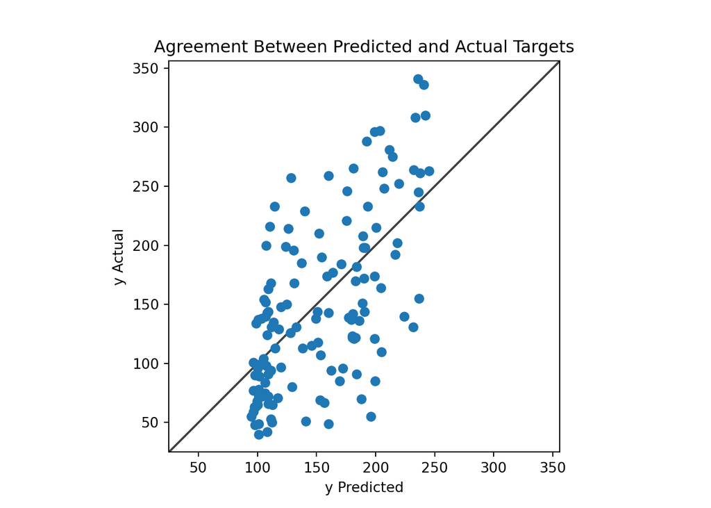

```python
# Plot
ax = plt.axes()
ax.set_title('Agreement Between Predicted and Actual Targets')
ax.scatter(y_pred, y_test.values)
lims = [
    np.min([ax.get_xlim(), ax.get_ylim()]),
    np.max([ax.get_xlim(), ax.get_ylim()])
]
ax.plot(lims, lims, 'k-', alpha=0.75, zorder=0)
ax.set_aspect('equal')
ax.set_xlim(lims)
ax.set_ylim(lims)
ax.set_xlabel('y Predicted')
ax.set_ylabel('y Actual')
plt.show()
plt.close()
```

# 9 Optimisation

The above agreement didn’t look very good; maybe we built the model badly by choosing a poor value for *k*? Let’s loop through a whole bunch of potential values for *k*, build a model for each, test it and record the best result:

```python
# Iterate over various values for k
scores = []
for k in range(1, 40):
    # Create a model and fit it to the data
    model = neighbors.KNeighborsRegressor(n_neighbors=k)
    model.fit(X_train, y_train)
    # Get the coefficient of determination of the prediction
    score = model.score(X_test, y_test)
    scores.append((score, k))
# Sort the results
scores_ordered = sorted(scores)

# Get the best result
print(scores_ordered[-1])
```

```
## (0.3895666165672974, 30)
```

Hmm, it seems that *k*=30 was indeed the optimal hyperparameter. This is the best we can do for this particular model for this particular dataset.

⇦ Back